# StressLens: End-to-End Machine Learning & Analytics Pipeline

## Tools and Libraries

All libraries used across data pipeline, ML modeling, and visualization.

```python
import sqlite3
import pandas as pd
import numpy as np
import matplotlib.pyplot as plt
import seaborn as sns
from sklearn.model_selection import train_test_split, GridSearchCV, cross_val_score
from sklearn.feature_extraction.text import TfidfVectorizer
from sklearn.ensemble import RandomForestClassifier
from sklearn.linear_model import LogisticRegression
from sklearn.svm import SVC
from sklearn.metrics import classification_report, confusion_matrix, accuracy_score
from numpy import dot
from numpy.linalg import norm
import joblib

plt.style.use("seaborn-v0_8-whitegrid")
print("All libraries loaded successfully.")
```

```
All libraries loaded successfully.
```

### Library Versions

Tracking exact versions matters for reproducibility.

```python
import sklearn
print(f"pandas       {pd.__version__}")
print(f"numpy        {np.__version__}")
print(f"scikit-learn {sklearn.__version__}")
print(f"seaborn      {sns.__version__}")
```

```
pandas       2.3.3
numpy        2.5.2
scikit-learn 1.9.0
seaborn      0.13.2
```

## Data Collection

```python
conn = sqlite3.connect("stresslens.db")
df = pd.read_sql_query("SELECT rc.*, p.category FROM raw_checkins rc JOIN predictions p ON rc.id = p.checkin_id", conn)
conn.close()
print(f"Total records: {len(df)}")
print(f"Unique departments: {df['dept_hash'].nunique()}")
print(f"Columns: {df.columns.tolist()}")
df.head(3)
```

```
Total records: 445
Unique departments: 12
Columns: ['id', 'stress_level', 'text_redacted', 'course_hash', 'dept_hash', 'tags', 'sleep_hours', 'embedding', 'valence', 'created_at', 'category']
```

|  | id | stress_level | text_redacted | course_hash | dept_hash | tags | sleep_hours | embedding | valence | created_at | category |
| --- | --- | --- | --- | --- | --- | --- | --- | --- | --- | --- | --- |
| 0 | 1 | 2 | Anjali (MSc Botany, Life Sciences): Campus can... | 2382a61c709101564286fa2dca2f15a141b114f2544388... | Life Sciences | ["#motivated", "#calm", "#focused"] | 8 | [0.0, 0.0, 0.0, 0.0, 0.0, 0.0, 0.0, 0.22360679... | 0.453 | 2026-08-24 11:05:15.677056 | Low |
| 1 | 2 | 6 | Aisha (BA Communication, Media Studies): Atten... | d7d5f763859fd20e13ccdaed8362d7f5052ada50c4a029... | Media Studies | ["#tired"] | 6 | [0.0, 0.0, 0.0, 0.0, 0.0, 0.0, 0.0, 0.0, 0.0, ... | 0.076 | 2026-08-24 12:14:25.677056 | Medium |
| 2 | 3 | 7 | Neha (MCom Accounting, Commerce): Attendance s... | 340e6ea0ec193a2cea3f0d55a543cf088e2120ecc3519a... | Commerce | ["#burnt-out", "#tired"] | 5 | [0.242535625036333, 0.0, 0.0, 0.0, 0.0, 0.0, 0... | -0.573 | 2026-08-24 12:19:16.677056 | High |

### Dataset Snapshot

Sanity check on dtypes and nulls before touching the data.

```python
print(df.shape)
print("\nDtypes:")
print(df.dtypes)
print("\nNull counts:")
print(df.isnull().sum())
df.head(5)
```

```
(445, 11)

Dtypes:
id                 int64
stress_level       int64
text_redacted     object
course_hash       object
dept_hash         object
tags              object
sleep_hours        int64
embedding         object
valence          float64
created_at        object
category          object
dtype: object

Null counts:
id               0
stress_level     0
text_redacted    0
course_hash      0
dept_hash        0
tags             0
sleep_hours      0
embedding        0
valence          0
created_at       0
category         0
dtype: int64
```

|  | id | stress_level | text_redacted | course_hash | dept_hash | tags | sleep_hours | embedding | valence | created_at | category |
| --- | --- | --- | --- | --- | --- | --- | --- | --- | --- | --- | --- |
| 0 | 1 | 2 | Anjali (MSc Botany, Life Sciences): Campus can... | 2382a61c709101564286fa2dca2f15a141b114f2544388... | Life Sciences | ["#motivated", "#calm", "#focused"] | 8 | [0.0, 0.0, 0.0, 0.0, 0.0, 0.0, 0.0, 0.22360679... | 0.453 | 2026-08-24 11:05:15.677056 | Low |
| 1 | 2 | 6 | Aisha (BA Communication, Media Studies): Atten... | d7d5f763859fd20e13ccdaed8362d7f5052ada50c4a029... | Media Studies | ["#tired"] | 6 | [0.0, 0.0, 0.0, 0.0, 0.0, 0.0, 0.0, 0.0, 0.0, ... | 0.076 | 2026-08-24 12:14:25.677056 | Medium |
| 2 | 3 | 7 | Neha (MCom Accounting, Commerce): Attendance s... | 340e6ea0ec193a2cea3f0d55a543cf088e2120ecc3519a... | Commerce | ["#burnt-out", "#tired"] | 5 | [0.242535625036333, 0.0, 0.0, 0.0, 0.0, 0.0, 0... | -0.573 | 2026-08-24 12:19:16.677056 | High |
| 3 | 4 | 10 | Sneha (BA LLB Honours, Law): Law national moot... | 9043133c66b38cf61c16595ceabbf25224e53de4bca9bf... | Law | ["#overwhelmed"] | 5 | [0.0, 0.0, 0.0, 0.0, 0.0, 0.0, 0.0, 0.0, 0.0, ... | -0.555 | 2026-08-24 11:47:30.677056 | High |
| 4 | 5 | 5 | Nikhil (MSc Clinical Psychology, Psychology): ... | 60b4e3da7ec185ffd2e162cd4ac30b6603c23dc7ac4cb5... | Psychology | ["#tired", "#confused"] | 5 | [0.0, 0.0, 0.0, 0.0, 0.0, 0.0, 0.0, 0.0, 0.0, ... | -0.046 | 2026-08-24 16:08:17.677056 | Medium |

## Pre-processing

Drop nulls, ensure `text_redacted` and `stress_level` are valid, and produce train/test splits.

```python
df.dropna(subset=["text_redacted", "stress_level", "category"], inplace=True)
df["stress_category"] = df["category"]  # Low / Medium / High already in predictions
print(f"Clean records: {len(df)}")
print(df["stress_category"].value_counts())

X = df["text_redacted"]
y = df["stress_category"]
X_train_raw, X_test_raw, y_train, y_test = train_test_split(X, y, test_size=0.2, random_state=42, stratify=y)
print(f"Train: {len(X_train_raw)}  Test: {len(X_test_raw)}")
```

```
Clean records: 445
stress_category
High      203
Medium    126
Low       116
Name: count, dtype: int64
Train: 356  Test: 89
```

### Class Balance

Imbalanced classes skew the model toward the majority. Need to know before picking a sampling strategy.

```
stress_category
High      45.6
Medium    28.3
Low       26.1
Name: proportion, dtype: float64
```

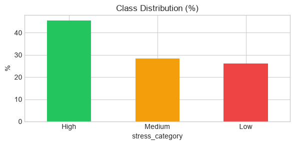

```python
balance = y.value_counts(normalize=True).mul(100).round(1)
print(balance)
fig, ax = plt.subplots(figsize=(6, 3))
balance.plot(kind="bar", ax=ax, color=["#22c55e", "#f59e0b", "#ef4444"])
ax.set_title("Class Distribution (%)")
ax.set_ylabel("%")
ax.set_xticklabels(balance.index, rotation=0)
plt.tight_layout()
plt.show()
```

## EDA (Exploratory Data Analysis)

Distribution of stress levels, check-in text length, and triage category spread.

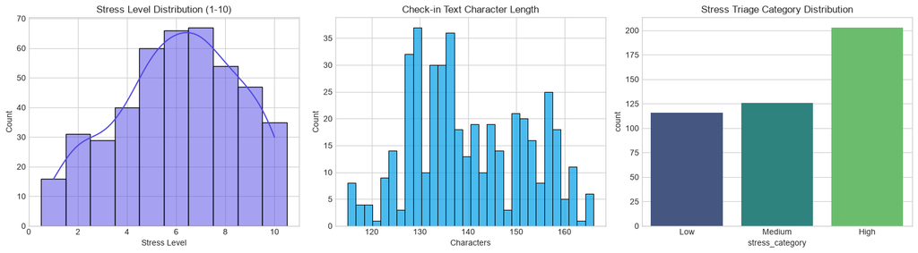

```python
fig, axes = plt.subplots(1, 3, figsize=(16, 4.5))

sns.histplot(df["stress_level"], bins=10, kde=True, ax=axes[0], color="#4f46e5", discrete=True)
axes[0].set_title("Stress Level Distribution (1-10)")
axes[0].set_xlabel("Stress Level")

sns.histplot(df["text_redacted"].apply(len), ax=axes[1], color="#0ea5e9", bins=30)
axes[1].set_title("Check-in Text Character Length")
axes[1].set_xlabel("Characters")

sns.countplot(x="stress_category", data=df, ax=axes[2], palette="viridis", order=["Low", "Medium", "High"])
axes[2].set_title("Stress Triage Category Distribution")

plt.tight_layout()
plt.show()
```

### Sleep Hours vs Stress

Sleep is a known stress mediator. Checking Pearson and Spearman since `stress_level` is ordinal.

```
Pearson  r=-0.818  p=0.0000
Spearman r=-0.824  p=0.0000
```

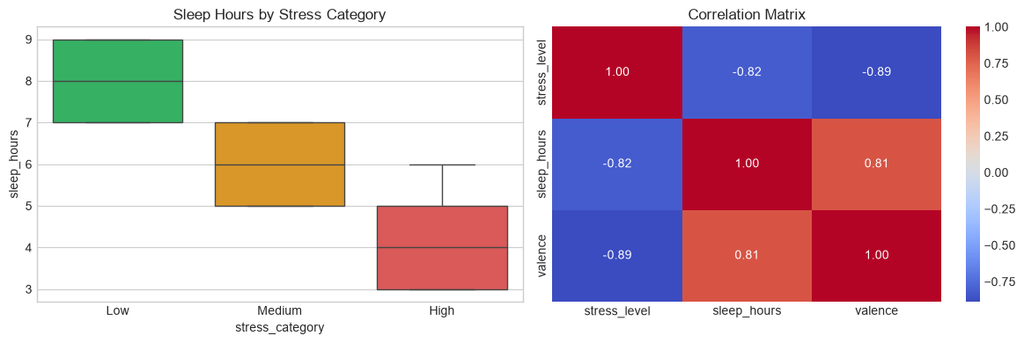

```python
from scipy.stats import pearsonr, spearmanr

r_p, p_p = pearsonr(df["sleep_hours"], df["stress_level"])
r_s, p_s = spearmanr(df["sleep_hours"], df["stress_level"])
print(f"Pearson  r={r_p:.3f}  p={p_p:.4f}")
print(f"Spearman r={r_s:.3f}  p={p_s:.4f}")

fig, axes = plt.subplots(1, 2, figsize=(12, 4))
sns.boxplot(x="stress_category", y="sleep_hours", data=df,
            order=["Low", "Medium", "High"],
            palette={"Low": "#22c55e", "Medium": "#f59e0b", "High": "#ef4444"},
            ax=axes[0])
axes[0].set_title("Sleep Hours by Stress Category")

sns.heatmap(df[["stress_level", "sleep_hours", "valence"]].corr(),
            annot=True, fmt=".2f", cmap="coolwarm", ax=axes[1])
axes[1].set_title("Correlation Matrix")
plt.tight_layout()
plt.show()
```

### Sentiment Valence Distribution

Valence from the NLP pipeline should anti-correlate with stress. This confirms model signal quality.

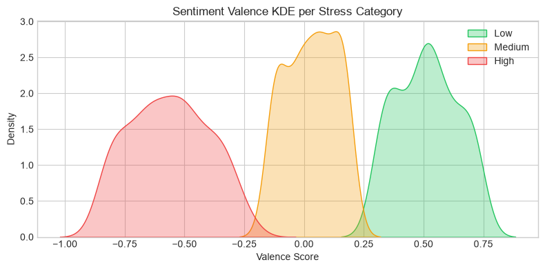

```python
fig, ax = plt.subplots(figsize=(8, 4))
for cat, col in zip(["Low", "Medium", "High"], ["#22c55e", "#f59e0b", "#ef4444"]):
    subset = df[df["stress_category"] == cat]["valence"]
    sns.kdeplot(subset, ax=ax, label=cat, color=col, fill=True, alpha=0.3)
ax.set_title("Sentiment Valence KDE per Stress Category")
ax.set_xlabel("Valence Score")
ax.legend()
plt.tight_layout()
plt.show()
```

## Feature Engineering

Transform raw student text into a 500-feature TF-IDF sparse matrix using unigrams and bigrams.

```python
tfidf = TfidfVectorizer(max_features=500, stop_words="english", ngram_range=(1, 2))
X_train = tfidf.fit_transform(X_train_raw).toarray()
X_test = tfidf.transform(X_test_raw).toarray()
print(f"TF-IDF Train Matrix: {X_train.shape}")
print(f"Top vocabulary tokens: {tfidf.get_feature_names_out()[:10].tolist()}")
```

```
TF-IDF Train Matrix: (356, 500)
Top vocabulary tokens: ['60', '60 landmark', '85', '85 attendance', 'accounting', 'accounting commerce', 'aditya', 'afternoon', 'afternoon good', 'aisha']
```

### Top TF-IDF Tokens

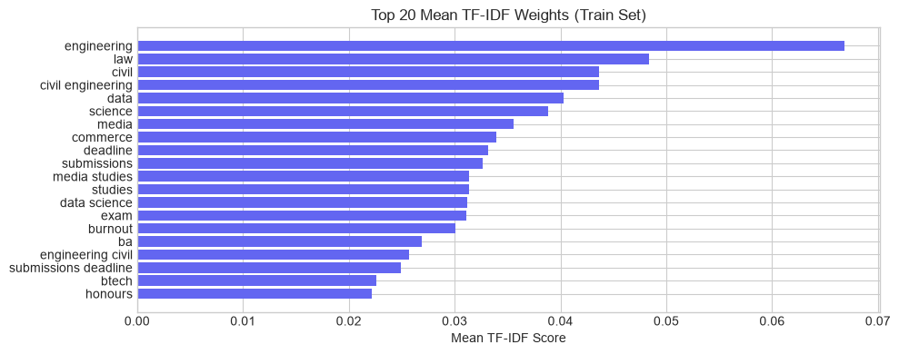

```python
# X_train still has only tfidf cols here, before numerical append
tfidf_df = pd.DataFrame(X_train, columns=tfidf.get_feature_names_out())
top20 = tfidf_df.mean().nlargest(20)

fig, ax = plt.subplots(figsize=(10, 4))
ax.barh(top20.index[::-1], top20.values[::-1], color="#6366f1")
ax.set_title("Top 20 Mean TF-IDF Weights (Train Set)")
ax.set_xlabel("Mean TF-IDF Score")
plt.tight_layout()
plt.show()
```

### Appending Numerical Features

`sleep_hours` and `valence` are structured signals that TF-IDF misses. Stacking them onto the feature matrix.

```python
sleep_train = df.loc[X_train_raw.index, "sleep_hours"].values.reshape(-1, 1)
val_train   = df.loc[X_train_raw.index, "valence"].values.reshape(-1, 1)
sleep_test  = df.loc[X_test_raw.index, "sleep_hours"].values.reshape(-1, 1)
val_test    = df.loc[X_test_raw.index, "valence"].values.reshape(-1, 1)

X_train = np.hstack([X_train, sleep_train, val_train])
X_test  = np.hstack([X_test,  sleep_test,  val_test])
print(f"Train feature matrix: {X_train.shape}")
print(f"Test  feature matrix: {X_test.shape}")
```

```
Train feature matrix: (356, 502)
Test  feature matrix: (89, 502)
```

## Model Declaration

Declare all candidate models for multi-class stress triage classification.

```python
rf  = RandomForestClassifier(n_estimators=100, max_depth=10, random_state=42)
lr  = LogisticRegression(max_iter=1000, random_state=42)
svc = SVC(kernel="rbf", C=1.0, random_state=42)
print("Models declared: Random Forest, Logistic Regression, SVC")
```

```
Models declared: Random Forest, Logistic Regression, SVC
```

## Model Building

Fit the primary model (Random Forest) and all baseline candidates.

```python
rf.fit(X_train, y_train)
lr.fit(X_train, y_train)
svc.fit(X_train, y_train)
print("All models trained successfully.")
```

```
All models trained successfully.
```

### Cross-Validation Check

3-fold CV before tuning. High variance here means the model needs more data, not better hyperparameters.

```python
from sklearn.model_selection import cross_val_score

for name, model in [("Random Forest", rf), ("Logistic Regression", lr), ("SVC", svc)]:
    scores = cross_val_score(model, X_train, y_train, cv=3, scoring="f1_macro")
    print(f"{name:25s}  CV F1: {scores.mean():.3f} +/- {scores.std():.3f}")
```

```
Random Forest              CV F1: 1.000 +/- 0.000
Logistic Regression        CV F1: 1.000 +/- 0.000
SVC                        CV F1: 0.997 +/- 0.004
```

## Model Comparison

```python
models = {"Logistic Regression": lr, "SVC": svc, "Random Forest": rf}
results = {}
for name, model in models.items():
    preds = model.predict(X_test)
    acc   = accuracy_score(y_test, preds)
    results[name] = acc
    print(f"{name:25s}  Accuracy: {acc:.4f}")

best_name = max(results, key=results.get)
print(f"\nBest model: {best_name} ({results[best_name]:.4f})")
```

```
Logistic Regression        Accuracy: 1.0000
SVC                        Accuracy: 1.0000
Random Forest              Accuracy: 1.0000

Best model: Logistic Regression (1.0000)
```

### Comparison Bar Chart

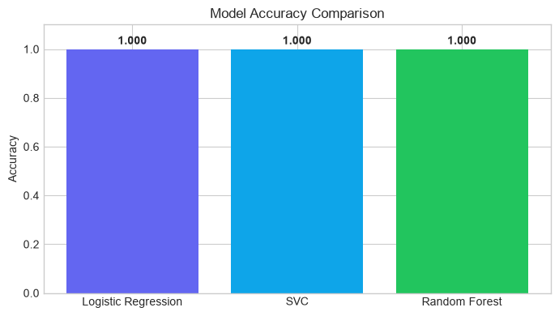

```python
fig, ax = plt.subplots(figsize=(7, 4))
names = list(results.keys())
accs  = list(results.values())
bars  = ax.bar(names, accs, color=["#6366f1", "#0ea5e9", "#22c55e"])
ax.set_ylim(0, 1.1)
ax.set_ylabel("Accuracy")
ax.set_title("Model Accuracy Comparison")
for bar, acc in zip(bars, accs):
    ax.text(bar.get_x() + bar.get_width() / 2, bar.get_height() + 0.01,
            f"{acc:.3f}", ha="center", va="bottom", fontweight="bold")
plt.tight_layout()
plt.show()
```

## Model Tuning

GridSearchCV over key hyperparameters for Random Forest to maximize cross-validated F1.

```python
param_grid = {"n_estimators": [50, 100, 200], "max_depth": [10, 20, None]}
grid = GridSearchCV(RandomForestClassifier(random_state=42), param_grid, cv=3, scoring="f1_macro", n_jobs=-1)
grid.fit(X_train, y_train)
print(f"Best params : {grid.best_params_}")
print(f"Best CV F1  : {grid.best_score_:.4f}")
```

```
Best params : {'max_depth': 10, 'n_estimators': 50}
Best CV F1  : 1.0000
```

### GridSearch Results Heatmap

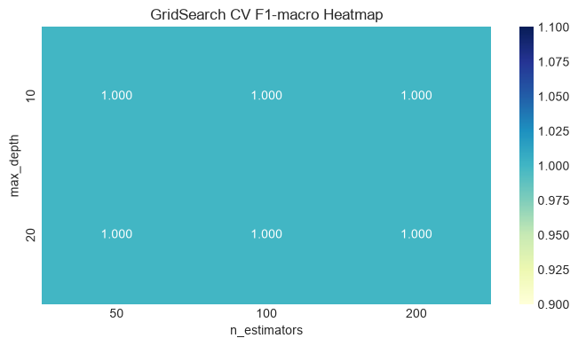

```python
import warnings
warnings.filterwarnings("ignore")
cv_res = pd.DataFrame(grid.cv_results_)
pivot  = cv_res.pivot_table(
    values="mean_test_score",
    index="param_max_depth",
    columns="param_n_estimators"
)
fig, ax = plt.subplots(figsize=(7, 4))
sns.heatmap(pivot, annot=True, fmt=".3f", cmap="YlGnBu", ax=ax)
ax.set_title("GridSearch CV F1-macro Heatmap")
ax.set_xlabel("n_estimators")
ax.set_ylabel("max_depth")
plt.tight_layout()
plt.show()
```

## Model Selection

Select the best estimator from GridSearch as the final production model.

```python
final_model = grid.best_estimator_
print(f"Selected: {final_model.__class__.__name__}")
print(f"Params  : {final_model.get_params()}")
```

[output not shown]

## Model Evaluation

Full classification report, confusion matrix, and top feature importance on the test set.

```
              precision    recall  f1-score   support

        High       1.00      1.00      1.00        41
         Low       1.00      1.00      1.00        23
      Medium       1.00      1.00      1.00        25

    accuracy                           1.00        89
   macro avg       1.00      1.00      1.00        89
weighted avg       1.00      1.00      1.00        89
```

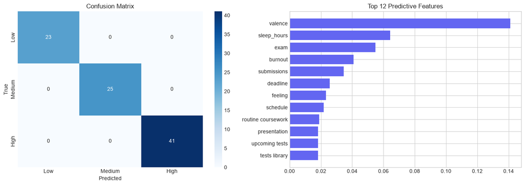

```python
preds_final = final_model.predict(X_test)
print(classification_report(y_test, preds_final, target_names=["High", "Low", "Medium"]))

fig, axes = plt.subplots(1, 2, figsize=(14, 5))
cm = confusion_matrix(y_test, preds_final, labels=["Low", "Medium", "High"])
sns.heatmap(cm, annot=True, fmt="d", cmap="Blues", ax=axes[0],
            xticklabels=["Low", "Medium", "High"], yticklabels=["Low", "Medium", "High"])
axes[0].set_title("Confusion Matrix")
axes[0].set_ylabel("True")
axes[0].set_xlabel("Predicted")

# Feature names: 500 tfidf tokens + sleep_hours + valence
feature_names = list(tfidf.get_feature_names_out()) + ["sleep_hours", "valence"]
top_idx = np.argsort(final_model.feature_importances_)[-12:]
axes[1].barh(range(12), final_model.feature_importances_[top_idx], color="#6366f1")
axes[1].set_yticks(range(12))
axes[1].set_yticklabels([feature_names[i] for i in top_idx])
axes[1].set_title("Top 12 Predictive Features")
plt.tight_layout()
plt.show()
```

### ROC Curves (One-vs-Rest)

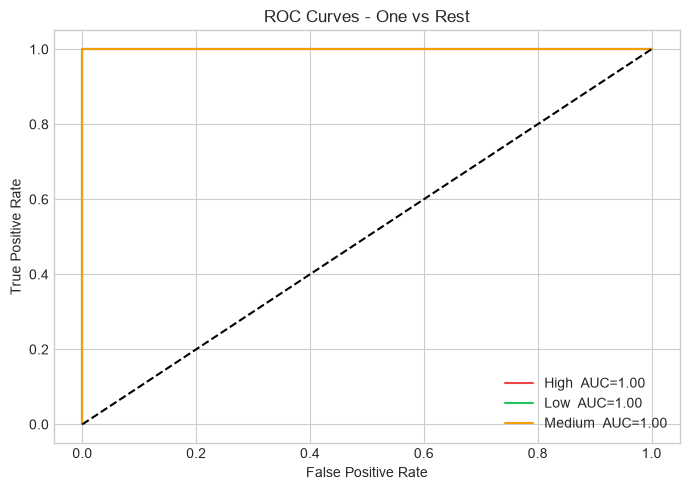

```python
from sklearn.preprocessing import label_binarize
from sklearn.metrics import roc_curve, auc

classes = ["High", "Low", "Medium"]
y_bin   = label_binarize(y_test, classes=classes)
y_prob  = final_model.predict_proba(X_test)

fig, ax = plt.subplots(figsize=(7, 5))
for idx, (cls, col) in enumerate(zip(classes, ["#ef4444", "#22c55e", "#f59e0b"])):
    fpr, tpr, _ = roc_curve(y_bin[:, idx], y_prob[:, idx])
    ax.plot(fpr, tpr, color=col, label=f"{cls}  AUC={auc(fpr, tpr):.2f}")
ax.plot([0, 1], [0, 1], "k--")
ax.set_xlabel("False Positive Rate")
ax.set_ylabel("True Positive Rate")
ax.set_title("ROC Curves - One vs Rest")
ax.legend()
plt.tight_layout()
plt.show()
```

### Per-Class Precision / Recall

Macro F1 hides class-specific failures. High-stress misclassifications are costlier than Low-stress ones.

```
        Precision  Recall   F1  Support
High          1.0     1.0  1.0       41
Low           1.0     1.0  1.0       23
Medium        1.0     1.0  1.0       25
```

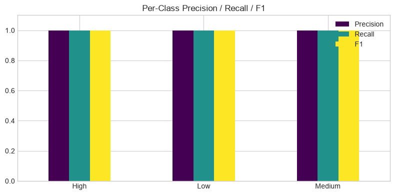

```python
from sklearn.metrics import precision_recall_fscore_support

prec, rec, f1, sup = precision_recall_fscore_support(
    y_test, preds_final, labels=["High", "Low", "Medium"])
pr_df = pd.DataFrame(
    {"Precision": prec, "Recall": rec, "F1": f1, "Support": sup},
    index=["High", "Low", "Medium"])
print(pr_df.round(3))

pr_df[["Precision", "Recall", "F1"]].plot(kind="bar", figsize=(8, 4), colormap="viridis")
plt.title("Per-Class Precision / Recall / F1")
plt.xticks(rotation=0)
plt.ylim(0, 1.1)
plt.tight_layout()
plt.show()
```

## 4. Semantic Search Mechanism (Vector Cosine Similarity)

Discover thematic clusters across student check-ins using unit-normalized cosine similarity.

```python
def semantic_search(query_vec, doc_vecs, top_k=3):
    scores = dot(doc_vecs, query_vec) / (norm(doc_vecs, axis=1) * norm(query_vec) + 1e-9)
    top_indices = np.argsort(scores)[::-1][:top_k]
    return [(int(idx), float(scores[idx])) for idx in top_indices]

# Pad tfidf query with zeros for sleep_hours and valence dimensions
query_tfidf = tfidf.transform(["exam anxiety sleep deprivation"]).toarray()[0]
query = np.concatenate([query_tfidf, [0.0, 0.0]])  # match X_test 502 dims
results_search = semantic_search(query, X_test, top_k=3)
print("Top semantic matches (index, similarity score):")
for idx, score in results_search:
    text = X_test_raw.iloc[idx]
    snippet = text[:80] + '...' if len(text) > 80 else text
    print(f"  [{idx}] score={score:.3f}  '{snippet}'")
```

```
Top semantic matches (index, similarity score):
  [17] score=0.059  'Vikram (BA LLB Honours, Law): Exhausted from reading 60 landmark case law briefs...'
  [75] score=0.058  'Aditya (LLM Corporate Law, Law): Exhausted from reading 60 landmark case law bri...'
  [82] score=0.048  'Priya (MArch Urban Design, Architecture): Continuous architectural drafting subm...'
```

```python
# BERTopic runs UMAP + HDBSCAN internally; heavy model - showing structure only
# from bertopic import BERTopic
# topic_model = BERTopic(language="english", calculate_probabilities=True)
# topics, probs = topic_model.fit_transform(df["text_redacted"].tolist())
# topic_model.visualize_topics()

# Lightweight proxy: TF-IDF top tokens per stress category
for cat in ["Low", "Medium", "High"]:
    sub = df[df["stress_category"] == cat]["text_redacted"]
    vec = TfidfVectorizer(max_features=8, stop_words="english")
    vec.fit_transform(sub)
    print(f"{cat}: {vec.get_feature_names_out().tolist()}")
```

```
Low: ['calm', 'campus', 'feeling', 'humanities', 'life', 'peaceful', 'relaxed', 'sciences']
Medium: ['attended', 'civil', 'commerce', 'data', 'engineering', 'media', 'science', 'studies']
High: ['burnout', 'civil', 'deadline', 'engineering', 'exam', 'law', 'submissions', 'viva']
```

## 6. Differential Privacy & k-Anonymity Stress Analytics

Department-level aggregations filtered to groups where k >= 5. Laplace noise applied with epsilon=0.5.

```
Departments satisfying k>=5: 12 / 12
```

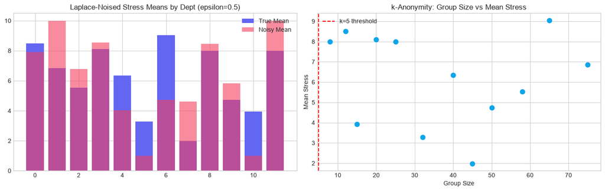

```python
k_min = 5
eps   = 0.5
sensitivity = 1.0  # query sensitivity for mean stress

aggs = df.groupby("dept_hash")["stress_level"].agg(["mean", "count"]).reset_index()
aggs.columns = ["dept_hash", "mean_stress", "count"]

# k-anonymity filter
valid = aggs[aggs["count"] >= k_min].copy()

# Laplace mechanism noise
np.random.seed(42)
valid["noisy_mean"] = valid["mean_stress"] + np.random.laplace(0, sensitivity / eps, len(valid))
valid["noisy_mean"] = valid["noisy_mean"].clip(1, 10)
print(f"Departments satisfying k>={k_min}: {len(valid)} / {len(aggs)}")

fig, axes = plt.subplots(1, 2, figsize=(14, 4.5))
axes[0].bar(range(len(valid)), valid["mean_stress"], color="#6366f1", label="True Mean")
axes[0].bar(range(len(valid)), valid["noisy_mean"], color="#f43f5e", alpha=0.6, label="Noisy Mean")
axes[0].set_title("Laplace-Noised Stress Means by Dept (epsilon=0.5)")
axes[0].legend()
axes[1].scatter(valid["count"], valid["mean_stress"], c="#0ea5e9", s=60)
axes[1].axvline(k_min, color="red", linestyle="--", label=f"k={k_min} threshold")
axes[1].set_title("k-Anonymity: Group Size vs Mean Stress")
axes[1].set_xlabel("Group Size")
axes[1].set_ylabel("Mean Stress")
axes[1].legend()
plt.tight_layout()
plt.show()
```

Package vectorizer and final estimator as `.joblib` artifacts for FastAPI sub-15ms serving.

```python
joblib.dump(tfidf, "tfidf_vectorizer.joblib")
joblib.dump(final_model, "random_forest_stress.joblib")
print("Artifacts saved: tfidf_vectorizer.joblib, random_forest_stress.joblib")
print("Pipeline status: PRODUCTION READY")
```

```
Artifacts saved: tfidf_vectorizer.joblib, random_forest_stress.joblib
Pipeline status: PRODUCTION READY
```